# NYC Bike Ridership and Violation Data Analysis

2023-10-05

# NYC Bike Violations

## Introduction

Throughout this report, I will use the term ‘cyclist’ to refer to regular bike riders, ebike riders, and escooter riders and ‘bicycle’ to refer to any of the vehicles that falls under these labels.

## Data

### Datasets

The datasets used were all taken from the NYC Open Data website, except the violation code description data, which was taken from the NY DMV website. The violation data was merged from two different datasets, a ‘year to date’ dataset spanning Jan 1, 2023 to June 30th, 2023, and a ‘historical’ dataset dating from Jan 1, 2018 to December 31, 2022. These datasets contained all violations issued by the NYPD, but only the violations labeled ‘Bike’, ‘Ebike’, and ‘Escooter’ were chosen for this report. The bicycle count data was agglomerated per day and per week, and these values were appended to the merged violations dataset. The violation code description data was also merged with the violations dataset, so that a textual description of the violation code could easily be accessed.

### Bike Counters

[interactive chart not shown]

*Bicycle counter locations throughout the 5 boroughs. Note that two on Amserdam Ave on the west side of Central Park have the exact same latitude and longitude in the .csv file, but in reality one is on Amsterdam ave collecting uptown traffic and the other is an avenue over on Columbus Ave, counting downtown traffic.*

The bicycle count data were taken from 18 separate bike counters, spread throughought the 5 boroughs, as can be seen in the map above. Although a total of 29 were listed in the .csv file, some of those were either duplicates or not applicable (ie - they only counted pedestrians) and were removed from consideration. The majority of these counters could be considered ‘Manhattan-centric.’ For instance, there is only one counter in Staten Island by the ferry access to Manhattan, one in a single area in the south Bronx, and only three in Queens, with one of those placed near the Queensboro bridge to Manhattan. Based on this unequal representation, I chose not to perform any borough specific analyses involving rider count data (however, violation data was not dependent on bike counters), and any generalizations or take-aways from this report should keep these limitations in mind. The bike counters acted by counting the number of cyclists that crossed them, and recording this aggregation every 15 minutes. The bike counter data ranged from 2012 to present, but only the data from 2018 to present were used.

### Removal of NA values

Of the 126,812 initial violation entries in the specified time frame, 111 total entries were removed, leaving 126,701. Sixteen rows did not contain violations codes, 92 rows did not contain city name or location information, and 3 rows did not contain location information.

## EDA

### Daily Total Cyclists

Top 10 Busiest Cycling Days

| Violation Date | Daily Total Cyclists |
| --- | --- |
| 2019-10-30 | 59750 |
| 2019-11-04 | 59291 |
| 2019-11-05 | 58329 |
| 2020-09-12 | 57637 |
| 2019-11-27 | 57456 |
| 2019-07-16 | 57394 |
| 2019-11-06 | 57384 |
| 2019-11-26 | 57323 |
| 2020-06-13 | 57195 |
| 2020-11-07 | 56453 |

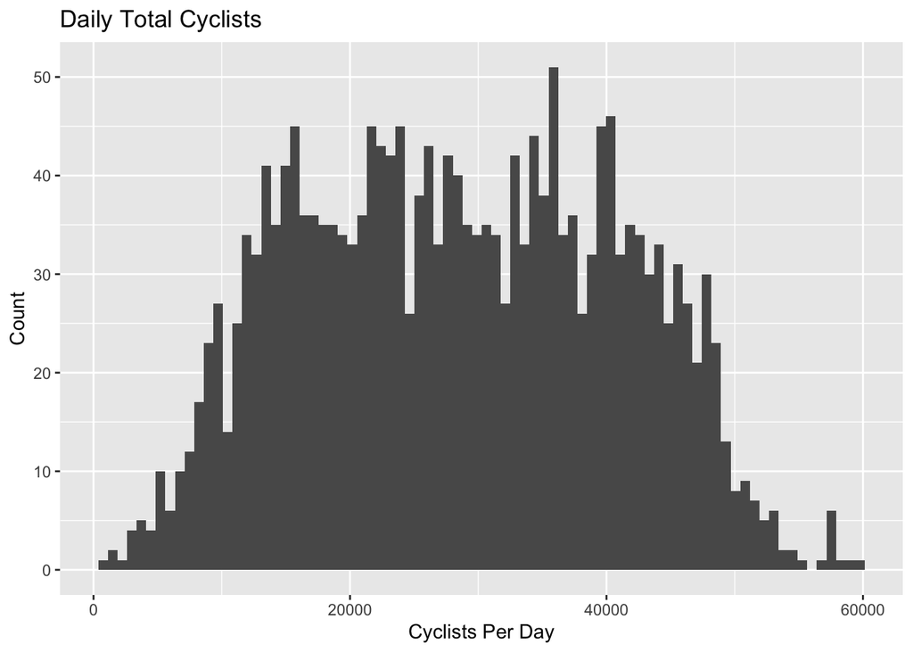

### Daily Totaly Cyclists over Time

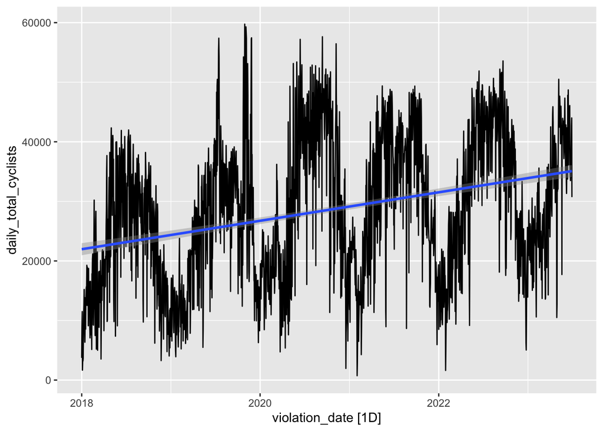

From the plot of daily total cyclists a general increasing trend can be seen, as well as strong seasonality. There are more cyclists in the warmer summer months than in the colder months. The slope for the regression line is 6.537613, which indicates that there are on average approximately 6.5 new riders per day.

Let’s further explore the seasonality. It’s easier to view this with monthly totals:

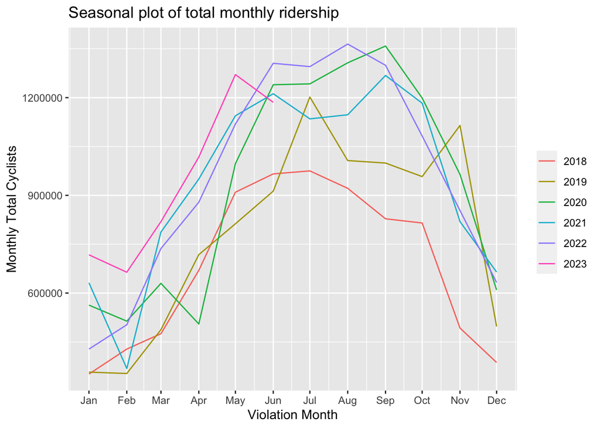

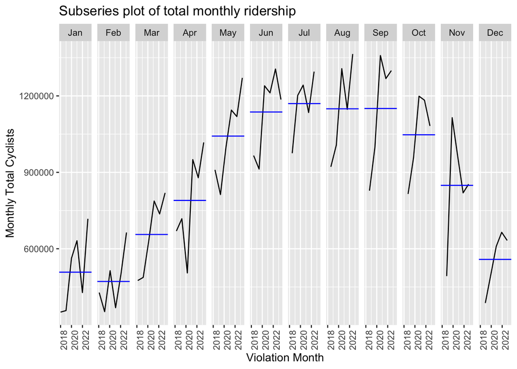

The increase in ridership in the warmer months can clearly be seen. Also note the yearly increase, as well as the dip in April of 2020 during covid lockdown.

#### Busiest Bike Counters

Busiest Bike Counters in 2022

1. Williamsburg side of Williamsburg bridge with 1964902
2. Queens side of Queensboro Bridge with 1818163:
3. Manhattan side of Manhattan bridge with 1584788:
4. Kent ave in Wburg with 1066870:
5. Brooklyn Bridge with 1002070:

The busiest bike counters in 2022 were at bridge access points as well as Kent ave in Williamsburg, which feeds onto the Wburg bridge. For 2023, up until June 30th, the order is mostly the same, with Kent ave and Brooklyn Bridge switching places. An analysis of daily total count data from just the Williamsburg bridge counter revealed similar trends to the total count data from all counters.

## Violations

#### Violations over time

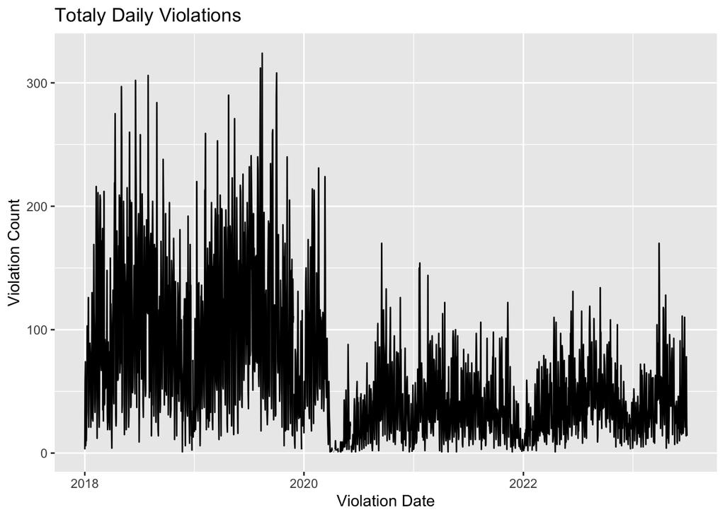

There were 126,701 total violations consisting of 188 different types of violations handed out to cyclists during the time frame this data was collected. As we can see from the daily violations plot, there was a sharp drop-off in violations handed out after covid lockdown.

Top 10 Violations

| Violation Code | Description | Total | Percent |
| --- | --- | --- | --- |
| 1111D1C | BICYCLE OR SKATEBOARD FAILED TO STOP AT RED LIGHT- NYC | 55933 | 44.1 |
| 1110AB | DISOBEYED TRAFFIC DEVICE WHILE OPERATING BICYCLE | 17166 | 13.5 |
| 1127AB | DRIVING WRONG DIRECTION ON ONE-WAY STREET - BICYCLE | 7995 | 6.3 |
| 403A3IX | BICYCLE FAILED TO YIELD TO VEHICLE/PEDESTRIAN AT RED LIGHT- NYC | 6682 | 5.3 |
| 37524AB | OPER BICYCLE WITH MORE 1 EARPHONE | 6052 | 4.8 |
| 1236B | NO BELL OR SIGNAL DEVICE ON BICYCLE | 3959 | 3.1 |
| 412P1 | BIKING OFF LANE- NYC | 3673 | 2.9 |
| 407C31 | BIKE/SKATE ON SIDEWALK-NYC | 3459 | 2.7 |
| 1232A | IMPROPER OPERATION OF BICYCLE | 2449 | 1.9 |
| 1111D1N | NYC REDLIGHT | 1925 | 1.5 |

From this table, we can see that improper traffic behavior at red lights (1111D1C, 403A3IX), account for ~50% of all bicycle violations. Other common violations include driving in the wrong direction, operating a bicycle with more than 1 earphone, not having a bell, and riding on the sidewalk.